# Predator_Prey_HW_Elting

Rosalee Elting

2023-02-01

# 1 Predator-Prey Models: Introduction

A more realistic model beyond the Lotka-Volterra Model, which allows for a limit on the L-V model’s shortcoming with infinite predator consumption when prey level are high. Here, we incorporate more variables, indicated in the variable index below by an **asterisk.**

# 2 Index of Variables in Model

$P$ - Predator number  
$N$ - Prey number  
$r$ - growth rate of prey  
$K$ - Carrying capacity or prey  
$u_{max}$ - maximum predation rate *  
$k_s$ - density of prey where Predator (P) eat 50% of their maximum rate *  
$b$ - conversion efficiency of prey biomass to predator biomass  
$d$ - predator death rate

# 3 Logistic Prey Model with a functional response

Following are two models, representing the change in prey and predators over time. They are as follows.

## 3.1 Prey Model

$$\frac{dN}{dt}=rN(1-\frac{N}{K}) -
\frac{u_{max}N}{k_s+N}\times P$$

## 3.2 Predator Model

$$\frac{dP}{dt}=
\frac{u_{max}N}{k_s+N}\times Pb - dP$$

# 4 Numerical Integration of the Logistic Prey Models

Below are the modified version of the above models that were transformed to represent numerical integration of the formulas for the prey and predator formulas.

## 4.1 Prey Formula

$$N_t = N_{t-1}+(rN_{t-1}\times (1-
\frac{N_{t-1}}{K}) - \frac {u_{max}N_{t-1}} {(K_s+N_{t-1})} \times
P_{t-1}) \Delta t$$

## 4.2 Predator Formula

$$P_t = P_{t-1} + (\frac
{u_{max}N_{t-1}}{(K_s + N_{t-1})} \times bP_{t-1} - dP_{t-1}) \Delta
t$$

# 5 Execution of the Numberical Integration of the Logistic Prey Model

Now that I have a numerical integration of this model, I will use this model to represent prey and predator relationships using the variables listed in the Index of Variables in Model.

## 5.1 Variables given

Included in this chunk are values of these variables given in the assignment.

```r
#length of run : 15000
n <- seq(from = 1, t =1500.1, by = 0.1)
#creating vectors to fill with prey and predator data
Nt <- NA
Pt <- NA
#Delta time or time steps
dt <- 0.1
#starting values for each data set
Nt[1] <- 20
Pt[1] <- 1
#known constant values
r <- 0.15

b <- 0.2
d <- 0.01

K <- 25
ks <- 20
umax <- 0.2
```

## 5.2 Loop to evaluate predator and prey numbers at each time step.

```r
for (i in 2: length(n)) {
  Nt[i] <- Nt[i-1] + (r*Nt[i-1]*(1-(Nt[i-1]/K))-(umax*Nt[i-1]/(ks + Nt[i-1]))*Pt[i-1])*(n[i]-n[i-1])
  Pt[i] <- Pt[i-1] + (umax*Nt[i-1]/(ks +Nt[i-1])*b*Pt[i-1] -d*Pt[i-1])*(n[i]-n[i-1])
}
```

# 6 Plots of Relationships

plot predators and prey as function of time and predator vs prey

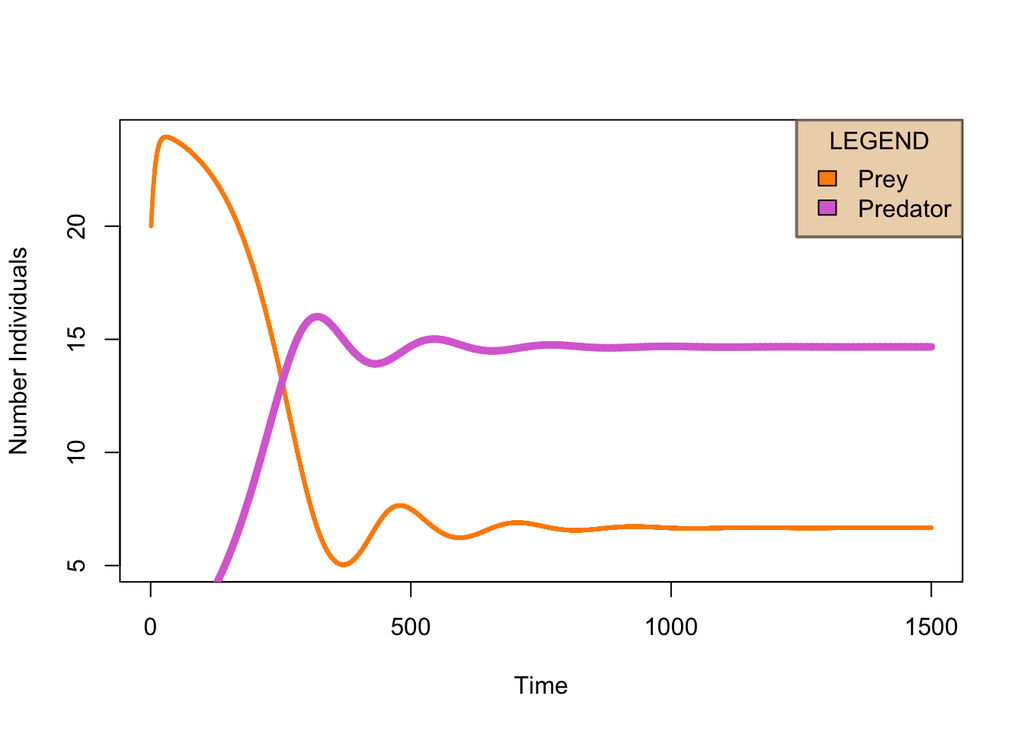

```r
plot(n, Nt, col = "darkorange", ylab = "Number Individuals", xlab = "Time", cex= 0.25)
lines(n, Pt, col= "orchid", legend = "Predator", lwd = 5)
# legend(legend=c("Prey", "Predator"),
#        fill = c("violet","darkblue"))
legend(x = "topright", box.col = "bisque4",
       bg ="bisque2", box.lwd = 2 , title="LEGEND",
       legend=c("Prey", "Predator"),
       fill = c("darkorange","orchid"))
```

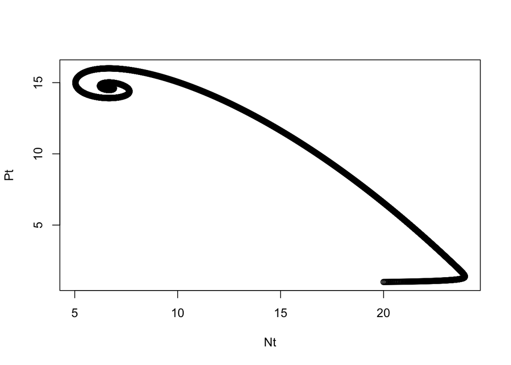

```r
plot(Nt, Pt)
```